# Song Project Stat 184

# unnest the tokens

```r
Graph5 <-
  Graph5 %>%
  group_by(decade) %>%
  summarise_at(vars(-sentiment, truthvalue), funs(mean(., na.rm = TRUE)))
```

#group the variables by decade variable, -sentiment orders the sentiment column, no empty values, and take the mean of truthvalue scores

```r
Graph5 <-
  Graph5 %>%
  anti_join(data_stopwords, by = c("word"="word")) %>%
  anti_join(stop_words, by = c("word"="word")) %>%
  mutate(decade = case_when( year %in% 1980:1989 ~ "1980s",
                             year %in% 1990:1999 ~ "1990s",
                             year %in% 2000:2009 ~ "2000s",
                             year %in% 2010:2019 ~ "2010s"))%>%
  inner_join(sentiments, by = "word") %>%
  group_by(year, decade, sentiment, truthvalue)
```

#specifying the decades using case_when

```r
Graph5 <-
  Graph5 %>%
  count(truthvalue)
```

#filtering truthvalues where its positive

```r
Graph5 <-
  Graph5 %>%
  filter(truthvalue ==1)
```

#the procedure for this graph is very similar to graph 4 instead we take the average per decade instead of graphing them year by year inside the decades. By filtering out the positive values (the values that can only increase the sentiment score) we take their mean per decade to compare with other decades.

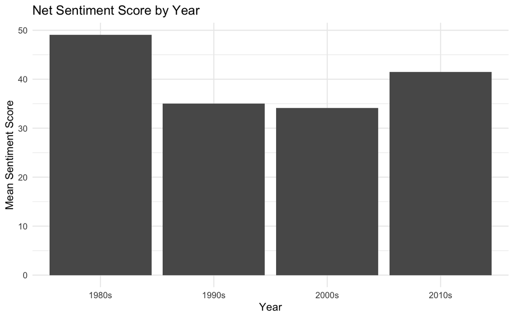

```r
Graph5 %>%
  ggplot(aes(x = decade, y=n))+
  aes((fill = decade))+
  ggtitle("Net Sentiment Score by Year")+
  geom_bar(stat = 'identity')+
  xlab("Year")+
  ylab("Mean Sentiment Score")+
  theme_minimal()+
  theme(legend.position = "none")
```

#Implementation of Graph 6

```r
Graph6 <- rbind(lyrics80s, lyrics90s, lyrics00s, lyrics10s)
```

```r
Graph6$year <- as.numeric(as.character(Graph6$year))
```

```r
Graph6 <-
  Graph6 %>%
  unnest_tokens(word, lyric)
```

```r
Graph6 <-
  Graph6 %>%
  anti_join(data_stopwords, by = c("word"="word")) %>%
  anti_join(stop_words, by = c("word"="word")) %>%
  mutate(decade = case_when( year %in% 1980:1989 ~ "1980s",
                             year %in% 1990:1999 ~ "1990s",
                             year %in% 2000:2009 ~ "2000s",
                             year %in% 2010:2019 ~ "2010s"))%>%
  inner_join(sentiments, by = "word") %>%
  group_by(year, decade, sentiment, truthvalue)
```

```r
Graph6 %>%
  ggplot(aes(x = decade, y=n))+
  aes((fill = decade))+
  ggtitle("Net Sentiment Score by Year of Grammy Nominated Records from 1980 - 2019")+
  geom_line(stat = 'identity')+
  geom_smooth()+
  xlab("Year")+
  ylab("Net Sentiment")+
  theme_minimal()
```

[output not shown]

#zoom recording link https://psu.zoom.us/rec/share/lQ91jvMinuHlKESrC4T8UJxdlnSV7vYoBAbzlVtc1MwywQB3qsg2l63iVqUcW0Mu.9zu47uRNlbZfUBu-